# ベイジアンデータ解析入門

第81回 日本心理学会TWS

比治山大学短期大学部 前田和寛

# はじめに

# 本TWSの構成

- ベイズ推論とベイジアンアプローチ  
  前田和寛(比治山大学短期大学部)
- ベイジアンになると何がどう変わるのか  
  小杉考司(山口大学教育学部)
- 回帰分析を例にベイジアンデータ解析を体験してみる  
  平川真(広島大学教育学研究科)

# 推論と確信度

# 推論してみよう

K氏が昨晩最初に飲んだビールは?

- A: アサヒスーパードライ
- B: キリン一番搾り
- C: サントリープレミアムモルツ
- D: サッポロ黒ラベル

# どのくらい確信できる?

- 情報がないのでどれかわからん
- どれも同じくらいにしか確信できない
- 四等分される

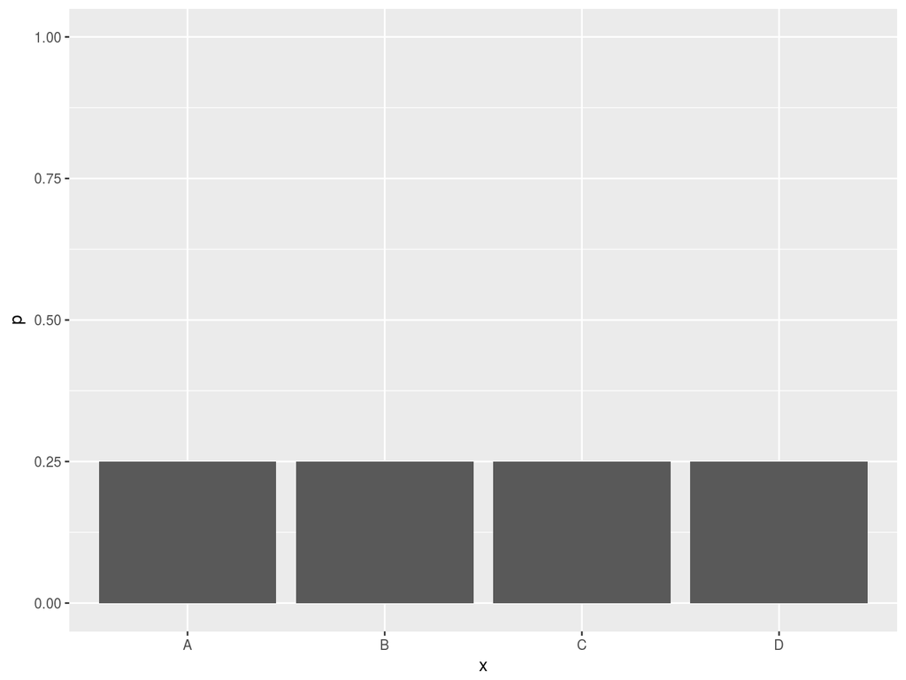

# 情報が追加

- 「Kはアサヒが苦手」という情報が追加
- Aである、という確信は下がる
- 減った分が他に**再配分**

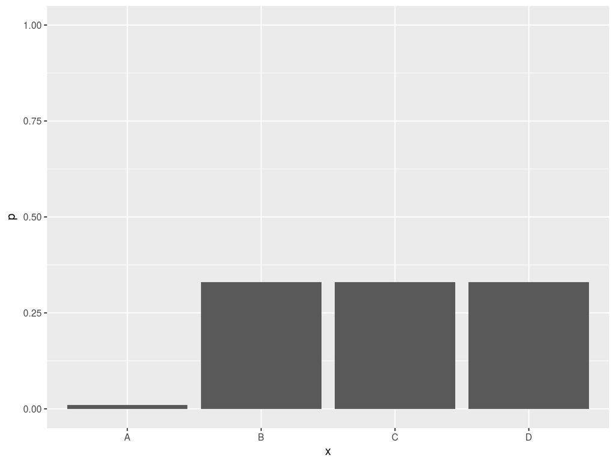

# さらに情報が追加

- 「Kは金欠で高いのは買わない」
- Cである、という確信は下がる
- 減った分が他に**再分配**

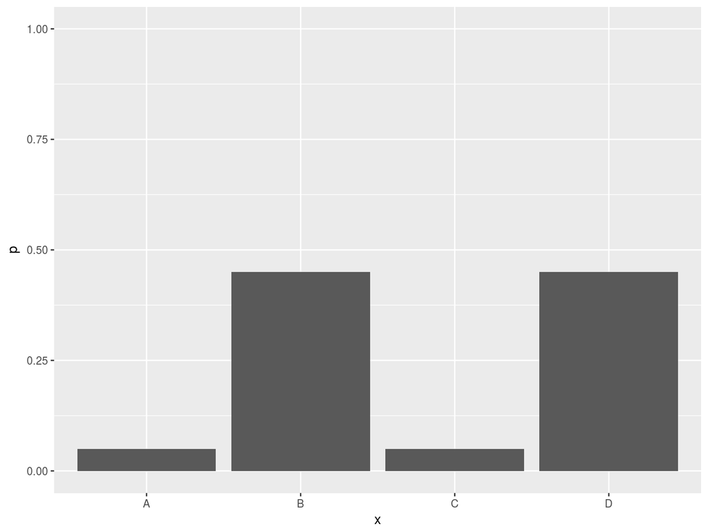

# さらにさらに情報が追加

- 「Kは黒ラベル推し」
- Dである、という確信が急上昇
- 残りを**再分配**

「きっとDだろう」という確信を持つ

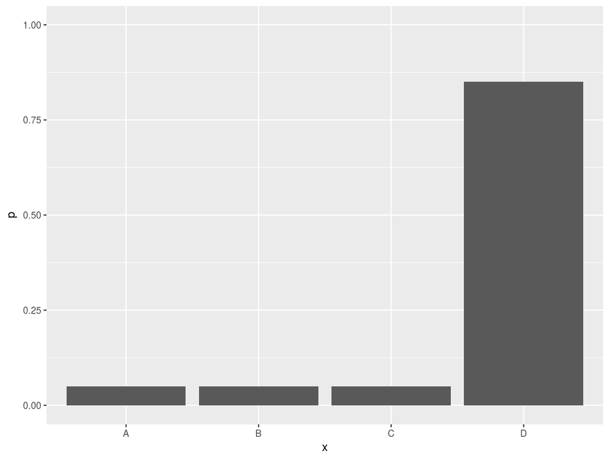

# 推論は確信度の再分配

情報(データ)が追加されることで、確信度が再分配される

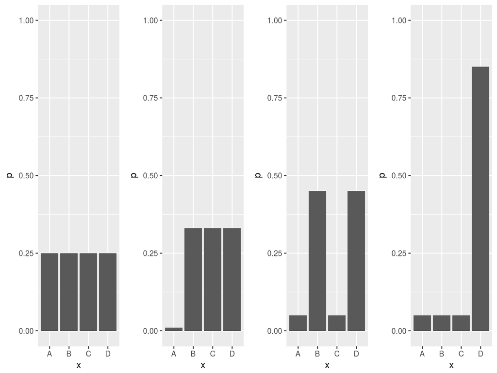

### つまり推論は…

- **可能性のある候補**があって、
- 各候補に、**事前にある程度持ってる確信度**があって、
- **情報(データ)が追加**され、
- 情報(データ)を鑑みた上で、**後の確信度**を変えていく

私達は、得られたデータを元に確信が持てる答えがほしい!

# ベイズ推論

# シンプルな例で考えてみる

K氏はどのくらいの確率でビールを飲むのか?

- 可能性のある候補は以下の2つ
  - A: ビールを飲む
  - B: ビールを飲まない
- どっちかわからない
  - 「まあ50:50ということで」
  - **0.5が一番確信が持てる値**と思える

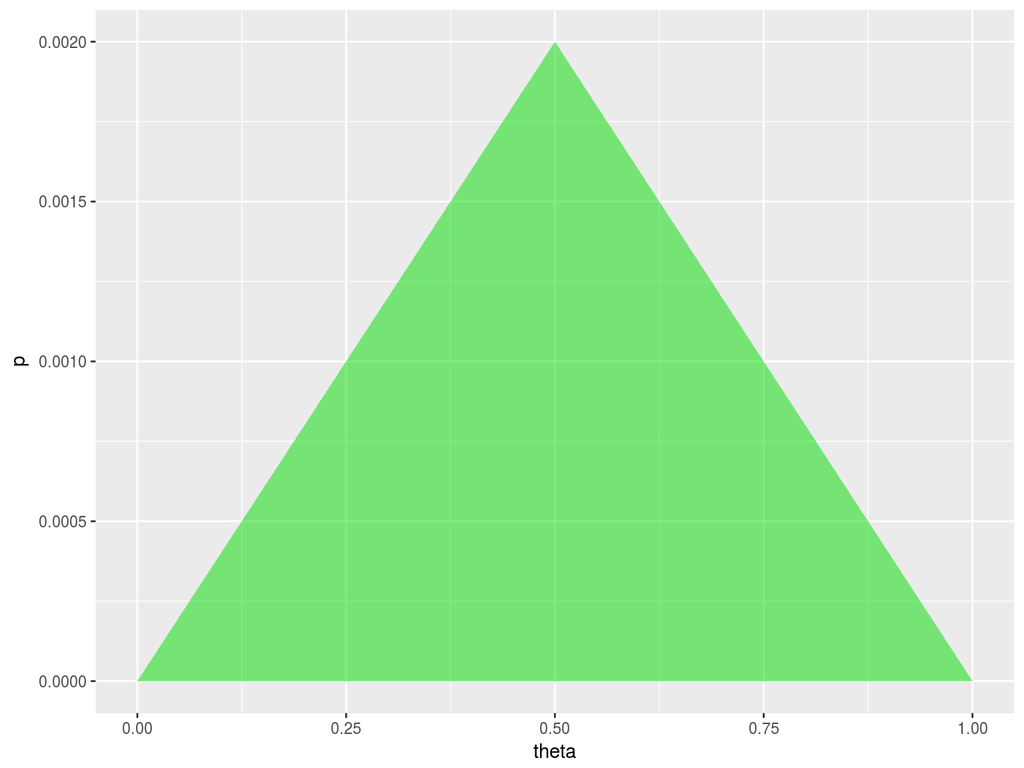

# データを集める

- 10日分のデータを取得したら，右のような結果に
  - これはいわゆる**エビデンス**
  - もうこれでいいんじゃない?
- でもこれは**たまたま10回分取り出した時の結果**
  - あるいは「**K氏が10回試行した結果**」とも

[figure not shown]

# 得られたデータとは?

- 測定したデータは何なのか?
  - 想定している母集団からサンプリング
  - 「一定の条件の下でデータを生成」ともみなせる
- この場合…
  - 「K氏は，ある確率$\theta$でビールを飲むという選択をする」かつ  
    「K氏は，ある確率$1-\theta$でビールを飲まないという選択をする」
  - つまりK氏は次々をデータを生成する**データ生成器**
- この$\theta$はいろんな値を取る
  - でもこの$\theta$をセットすると、ガチャガチャデータを生成
  - **パラメータ**として考えよう

# データから尤もらしいところを

| θ | 確率 |
| --- | --- |
| 0.0 | 0.0000000 |
| 0.1 | 0.0000001 |
| 0.2 | 0.0000066 |
| 0.3 | 0.0000750 |
| 0.4 | 0.0003539 |
| 0.5 | 0.0009766 |
| 0.6 | 0.0017916 |
| 0.7 | 0.0022236 |
| 0.8 | 0.0016777 |
| 0.9 | 0.0004783 |
| 1.0 | 0.0000000 |

# 尤もらしさを図にしてみる

- 右図の通り
  - 縦線は$\theta = 0.7$の場所
  - やはりそこが一番高い
- つまり、この分布が「データから言えるパラメータの分布」
  - これが**尤度関数**
  - そしてこの場合$\theta = 0.7$が最尤推定量

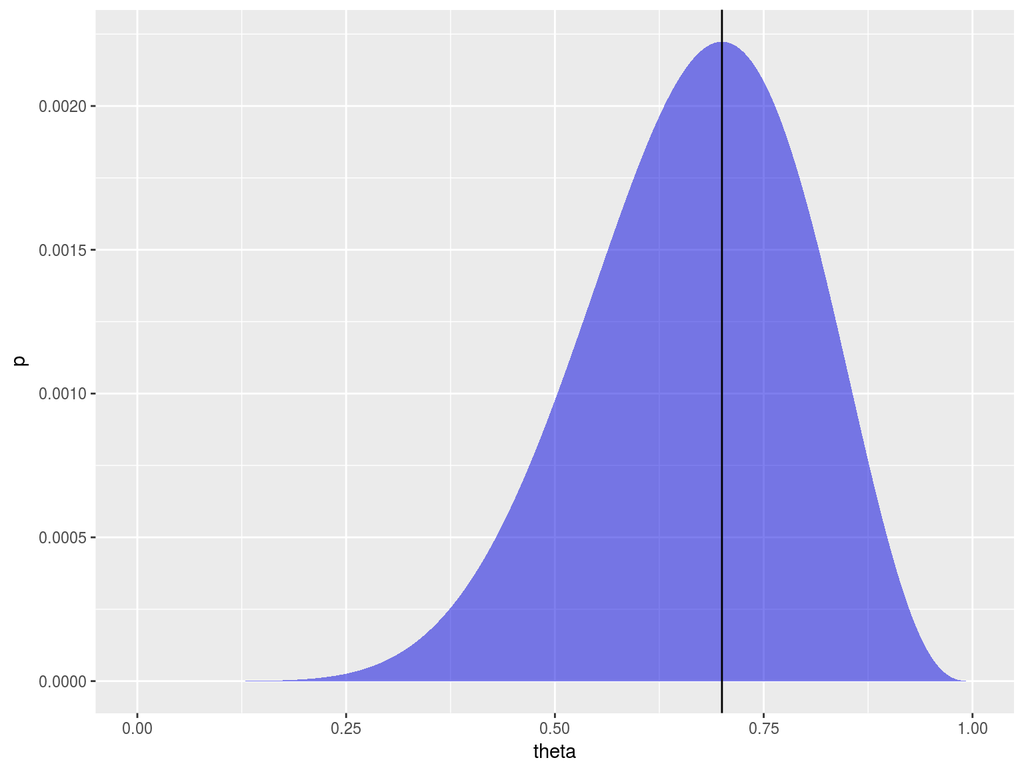

# もう一度整理しよう

推論したいパラメータ(K氏がビールを飲む確率)がある

- 漠然とした感覚がある
  - 「多分0.5くらいじゃね?」
  - **事前の確信度**
- それについてデータを取った
  - 「データからみたらこの辺っぽい」
  - **尤度関数**
- **データから、今までの感覚を更新したい**
  - データを得た**後**の確信度

# 材料は揃った

### 事前の確信度

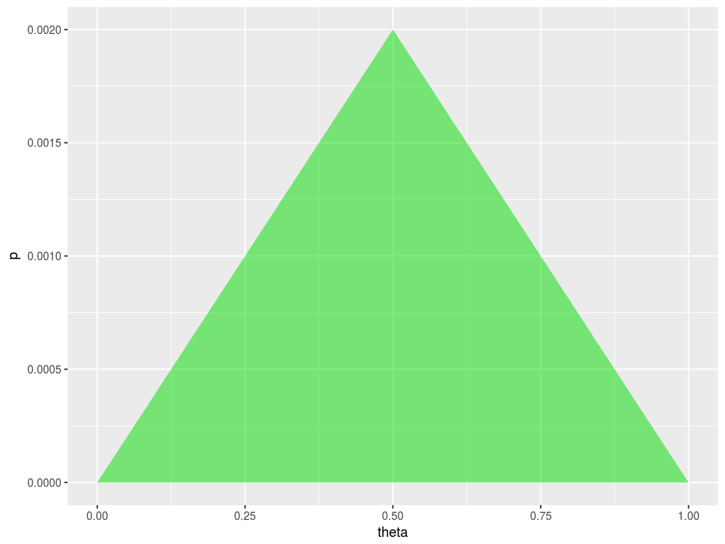

### データが示すもの

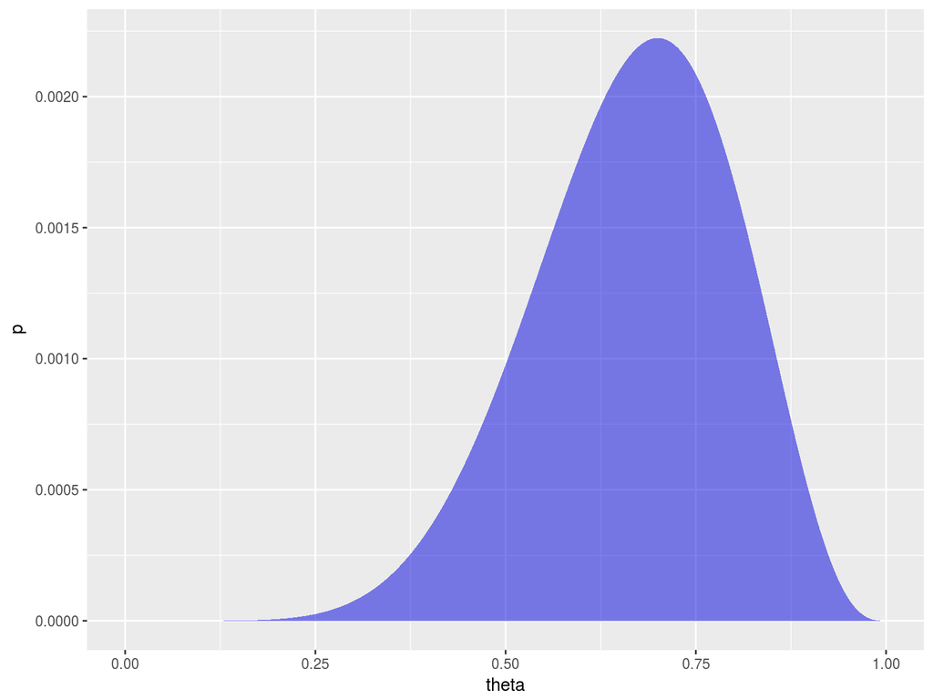

# 事前の予想 x 尤もらしさ

- 「K氏がビールを飲む確率はこんな感じであろう」

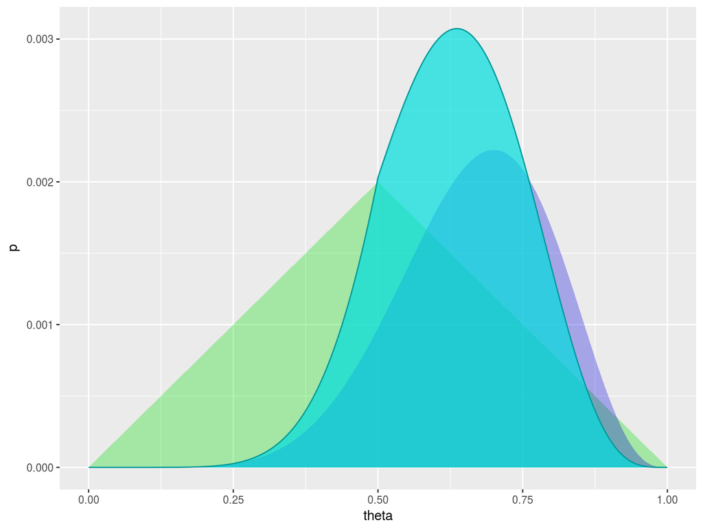

# これがベイズ推論

- 各項は以下の通り
  - $\theta$: パラメータ
  - $D$: データ
  - $P(\theta)$: データを考慮しない$\theta$の確率
  - $P(D)$: 可能性のある候補すべての確率
  - $P(D|\theta)$: $\theta$が与えられた場合の$D$の確率
  - $P(\theta|D)$: $D$が与えられた場合の$\theta$の確率

ベイズの定理:

$$P(\theta|D) = \frac{P(D|\theta)P(\theta)}{P(D)}$$

# もうちょっとわかりやすく

- 各項は以下の通り
  - $P(\theta)$: 事前の確信度  
    (**事前分布**)
  - $P(D)$: 各候補の確率  
    (**データ**)
  - $P(D|\theta)$: データに基づいた尤もらしさ  
    (**尤度関数**)
  - $P(\theta|D)$: データが与えられた後の確信度  
    (**事後分布**)

ベイズの定理:

$$P(\theta|D) = \frac{P(D|\theta)P(\theta)}{P(D)}$$

# まとめると…?

すごく大雑把にいうと、こんな感じです:

$$P(\theta|D) = P(D|\theta) \times P(\theta) \:/\: {P(D)}$$
$$事後分布 = 尤度 \times 事前分布 \:/\: エビデンス$$

- 私達がほしいのは事後分布
  - 尤度と事前分布から生成されている!
- **事後分布は尤度と事前分布の折衷となる**
- エビデンスは、得たデータから算出される候補の確率総和
  - **現実のところ、あまり気にしなくていい(後述)**

# ベイジアンアプローチとモデリング

# なぜ今まで使わなかったの?

- 今回の例では実際に数式で計算
  - 最小レベルでシンプルなものだったから
  - というか**連続変量を区切って離散的にやりました**
    - $\theta$は本来連続的
- 実際の分析では計算が厳しい
  - 連続変量が入ると積分がらみでまず無理
  - 推定したいパラメータは結構多い
    - 同時確率を求めることになる(たいへん)

**直接計算がむりなら、シミュレーションで近似しよう!**

# モデリングとシミュレーション

$$P(\theta|D) = P(D|\theta) \times P(\theta) \:/\: {P(D)}$$

$$事後分布 = 尤度 \times 事前分布 \:/\: エビデンス$$

- エビデンスは**所与のもの**
  - 要するに**定まった値(定数)**
- 尤度関数と事前分布で**確率モデルを作る**
  - 推定したいパラメータの事前分布を**こちらで設定**
  - 尤度関数を構築
- あとは，この**モデルの枠内で取りうる値をシミュレーション**!
  - そうここでMCMC!
  - シミュレーションで生成した値の分布を事後分布として近似しよう

# じゃあどうしたらいいの?

# いい本がありますよ、みなさん

[figure not shown]

- ベイズ統計モデリング―R,JAGS,Stanによるチュートリアル― 原著第2版
  - 原著はDoing Bayesian Data Analysis: A Tutorial with R, JAGS, and Stan 2nd Edition
- 共立出版より2017年07月26日に発売
- この1冊で理論的な部分，実践部分きっちりカバー
  - 先程までの話は，この本の2章と5章がベース
- 3部構成の25章まで
  - ほぼ全ての章にエクササイズ付属
- 全てR上で分析します
  - 書籍にある分析のRコードはダウンロード可能
- サポートサイトもあります
  - https://kazutan.github.io/DBDA2E-ja/
  - Twitterの**#犬4匹本** も是非
- こんな方におすすめ
  - ベイズ? なにそれ? な方
  - 従来の分析では厳しいモデルを検討したい方
  - Rでベイジアンモデリングをしたい方
  - デスクワークで最近運動不足気味な方

# 第I部の構成

- ベイズ推論の基礎を説明
- どうしても必要な確率，分布もみっちり
- そしてR入門も
2. 導入：確信度，モデル，パラメータ
3. R言語
4. 確率と呼ばれるものはいかなるものか？
5. ベイズの公式

# 第II部の構成

- コイントスというシンプルな事象に対して，詳細にベイズモデリングを説明
- ベイズモデリングを実践するにおいて重要なポイントを解説
- MCMCをするためのソフトウェアであるJAGSとStanについても
6. 正確な数学的分析による二項確率の推論
7. マルコフ連鎖モンテカルロ法
8. JAGS
9. 階層モデル
10. モデル比較と階層モデリング
11. 帰無仮説有意性検定
12. 点の（「帰無」）仮説検定に対するベイジアン・アプローチ
13. 目標，検定力，そしてサンプルサイズ
14. Stan

# 第III部の構成

一般化線形モデル(GLM)について，実践的な方法を解説:

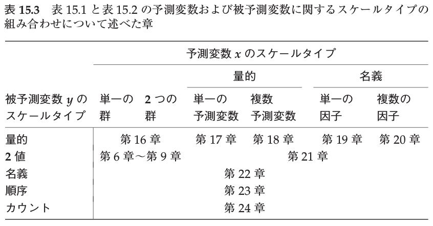

本書15章, p. 455より

# 他のおすすめ書籍

- ベイズ統計で実践モデリング 認知モデルのトレーニング
  - Bayesian Cognitive Modeling: A Practical Courseの翻訳
- 認知モデルを主な題材とし，具体的な例でひたすらエクササイズ!

[figure not shown]

# ここからのお話

# ベイジアンになると何がどう変わるのか

ベイズ統計を使うと今までの「仮説検定」「実験計画」の考え方がどのように変わるのか,を解説

- 頻度主義の考え方とベイジアンの考え方
- ベイズ流の帰無仮説検定はどのように行うか
- 従来の仮説検定の大問題とベイズ流のやり方による克服

# ベイジアンデータ解析を体験

回帰分析を例に，ベイジアンデータ解析を体験してみる

- データの特定
- モデルの定義
- パラメタの事前分布の設定
- ベイズ推論を用いて，パラメタの値に確信度を再分配
- 事後予測がデータを模倣できているかを確認